# 1713314_PDA

Bartosz Napieralski

4/4/2022

# Data

The data that our group is going to be using can be found here: https://www.kaggle.com/datasets/andrewmvd/heart-failure-clinical-data

## Reading and preparing the Dataset

```r
raw <- read.csv("heart_failure_clinical_records_dataset.csv")
#Looking for any missing data
table(is.na(raw))
```

```
##
## FALSE
##  3887
```

```r
#Removing any missing columns
data <- na.omit(raw)

#Quick summary of the data
summary(data)
```

```
##       age           anaemia       creatinine_phosphokinase    diabetes
##  Min.   :40.00   Min.   :0.0000   Min.   :  23.0           Min.   :0.0000
##  1st Qu.:51.00   1st Qu.:0.0000   1st Qu.: 116.5           1st Qu.:0.0000
##  Median :60.00   Median :0.0000   Median : 250.0           Median :0.0000
##  Mean   :60.83   Mean   :0.4314   Mean   : 581.8           Mean   :0.4181
##  3rd Qu.:70.00   3rd Qu.:1.0000   3rd Qu.: 582.0           3rd Qu.:1.0000
##  Max.   :95.00   Max.   :1.0000   Max.   :7861.0           Max.   :1.0000
##  ejection_fraction high_blood_pressure   platelets      serum_creatinine
##  Min.   :14.00     Min.   :0.0000      Min.   : 25100   Min.   :0.500
##  1st Qu.:30.00     1st Qu.:0.0000      1st Qu.:212500   1st Qu.:0.900
##  Median :38.00     Median :0.0000      Median :262000   Median :1.100
##  Mean   :38.08     Mean   :0.3512      Mean   :263358   Mean   :1.394
##  3rd Qu.:45.00     3rd Qu.:1.0000      3rd Qu.:303500   3rd Qu.:1.400
##  Max.   :80.00     Max.   :1.0000      Max.   :850000   Max.   :9.400
##   serum_sodium        sex            smoking            time
##  Min.   :113.0   Min.   :0.0000   Min.   :0.0000   Min.   :  4.0
##  1st Qu.:134.0   1st Qu.:0.0000   1st Qu.:0.0000   1st Qu.: 73.0
##  Median :137.0   Median :1.0000   Median :0.0000   Median :115.0
##  Mean   :136.6   Mean   :0.6488   Mean   :0.3211   Mean   :130.3
##  3rd Qu.:140.0   3rd Qu.:1.0000   3rd Qu.:1.0000   3rd Qu.:203.0
##  Max.   :148.0   Max.   :1.0000   Max.   :1.0000   Max.   :285.0
##   DEATH_EVENT
##  Min.   :0.0000
##  1st Qu.:0.0000
##  Median :0.0000
##  Mean   :0.3211
##  3rd Qu.:1.0000
##  Max.   :1.0000
```

## METADATA

Here is a breakdown of all of the :

- Age - Age
- Anaemia - Decrease of red blood cells or hemoglobin (0 = No, 1 = Yes)
- Creatinine_phosphokinase - Level of the CPK enzyme in the blood Normal Values range between 10 to 120 mcg/L https://www.mountsinai.org/health-library/tests/creatine-phosphokinase-test
- Diabetes - If the patient has diabetes (0 = No, 1 = Yes)
- Ejection_fraction - Percentage of blood leaving the heart at each contraction (percentage) Normal Values have a percentage of 40% EF or higher, abnormal is below 40 https://my.clevelandclinic.org/health/articles/16950-ejection-fraction
- High_blood_pressure - If the patient has hypertension (0 = No, 1 = Yes)
- Platelets - Platelets in the blood (kiloplatelets/mL) Normal amount of platelets is between 150,000 and 450,000 kiloplatelets/mL https://www.hopkinsmedicine.org/health/conditions-and-diseases/what-are-platelets-and-why-are-they-important#:~:text=A%20normal%20platelet%20count%20ranges,complete%20blood%20count%20(CBC).
- Serum_creatinine - Level of serum creatinine in the blood (mg/dL) For men it is 0.74-1.35mg/dL For wormen it is 0.59-1.04mg/dL https://www.mayoclinic.org/tests-procedures/creatinine-test/about/pac-20384646#:~:text=Serum%20creatinine%20level&text=The%20amount%20of%20creatinine%20in,blood%20(micromoles%2FL).
- Serum_sodium - Level of serum sodium in the blood (mEq/L) Normal levels are between 135-145 mEq/L https://www.mayoclinic.org/diseases-conditions/hyponatremia/symptoms-causes/syc-20373711#:~:text=A%20normal%20blood%20sodium%20level,Certain%20medications.
- Sex - Woman (0) or Man (1)
- smoking - If the patient smokes or not (0 = No, 1 = Yes)
- time - Follow up period (days)
- DEATH_EVENT - If the patient deceased during the follow up period (0 = No, 1 = Yes)

```r
#Adding ID to keep track of data
data$id <- seq.int(nrow(data))
data <- data %>% relocate(id)


#Assigning Character Value to correct parameters
data$sexCH <- ifelse(data$sex == 1, "Male", "Female")
data$sex <- as.logical(data$sex)
data$anaemiaCH <- ifelse(data$anaemia == 1, "Yes", "No")
data$anaemia <- as.logical(data$anaemia)
data$diabetesCH <- ifelse(data$diabetes == 1, "Yes", "No")
data$diabetes <- as.logical(data$diabetes)
data$high_blood_pressureCH <- ifelse(data$high_blood_pressure == 1, "Yes", "No")
data$high_blood_pressure <- as.logical(data$high_blood_pressure)
data$smokingCH <- ifelse(data$smoking == 1, "Yes", "No")
data$smoking <- as.logical(data$smoking)
data$DEATH_EVENT <- as.logical(data$DEATH_EVENT)


summary(data)
```

```
##        id             age         anaemia        creatinine_phosphokinase
##  Min.   :  1.0   Min.   :40.00   Mode :logical   Min.   :  23.0
##  1st Qu.: 75.5   1st Qu.:51.00   FALSE:170       1st Qu.: 116.5
##  Median :150.0   Median :60.00   TRUE :129       Median : 250.0
##  Mean   :150.0   Mean   :60.83                   Mean   : 581.8
##  3rd Qu.:224.5   3rd Qu.:70.00                   3rd Qu.: 582.0
##  Max.   :299.0   Max.   :95.00                   Max.   :7861.0
##   diabetes       ejection_fraction high_blood_pressure   platelets
##  Mode :logical   Min.   :14.00     Mode :logical       Min.   : 25100
##  FALSE:174       1st Qu.:30.00     FALSE:194           1st Qu.:212500
##  TRUE :125       Median :38.00     TRUE :105           Median :262000
##                  Mean   :38.08                         Mean   :263358
##                  3rd Qu.:45.00                         3rd Qu.:303500
##                  Max.   :80.00                         Max.   :850000
##  serum_creatinine  serum_sodium      sex           smoking
##  Min.   :0.500    Min.   :113.0   Mode :logical   Mode :logical
##  1st Qu.:0.900    1st Qu.:134.0   FALSE:105       FALSE:203
##  Median :1.100    Median :137.0   TRUE :194       TRUE :96
##  Mean   :1.394    Mean   :136.6
##  3rd Qu.:1.400    3rd Qu.:140.0
##  Max.   :9.400    Max.   :148.0
##       time       DEATH_EVENT        sexCH            anaemiaCH
##  Min.   :  4.0   Mode :logical   Length:299         Length:299
##  1st Qu.: 73.0   FALSE:203       Class :character   Class :character
##  Median :115.0   TRUE :96        Mode  :character   Mode  :character
##  Mean   :130.3
##  3rd Qu.:203.0
##  Max.   :285.0
##   diabetesCH        high_blood_pressureCH  smokingCH
##  Length:299         Length:299            Length:299
##  Class :character   Class :character      Class :character
##  Mode  :character   Mode  :character      Mode  :character
##
##
##
```

```r
write.csv(data, "./data.csv", row.names = FALSE)
```

# Data Exploration

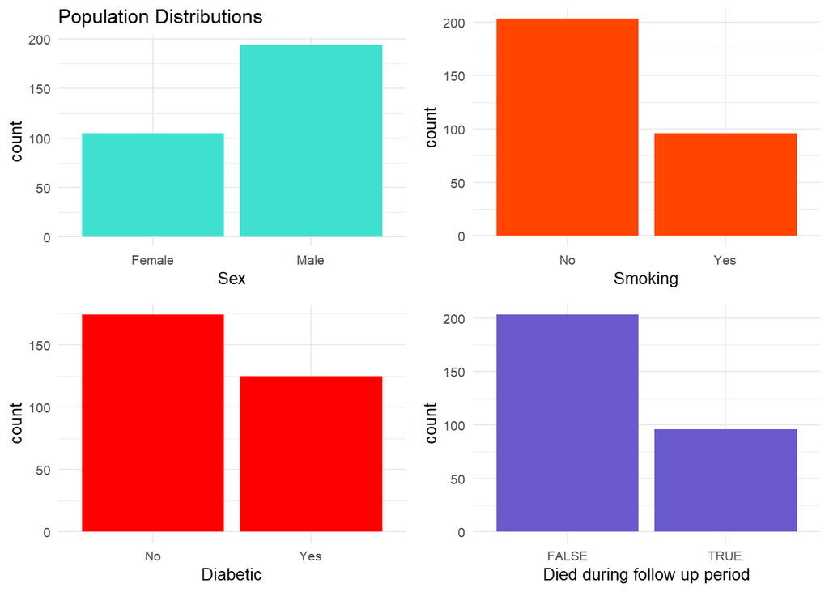

```r
# Since I am using large amounts of data, we can look at the population of the data

# Sex
plotSex <- ggplot(data, aes(x = sexCH)) + geom_bar(fill = "turquoise") + labs(x = "Sex", title = "Population Distributions") + theme_minimal(base_size = 10)
plotSmoke <- ggplot(data, aes(x = smokingCH)) + geom_bar(fill = "orangered") + labs(x = "Smoking") +theme_minimal(base_size = 10)
plotDiab <- ggplot(data, aes(x = diabetesCH)) + geom_bar(fill = "red") + labs(x = "Diabetic") +theme_minimal(base_size = 10)
plotDeath <- ggplot(data, aes(x = DEATH_EVENT)) + geom_bar(fill = "slateblue") + labs(x = "Died during follow up period") +theme_minimal(base_size = 10)

ggarrange(plotSex, plotSmoke, plotDiab, plotDeath)
```

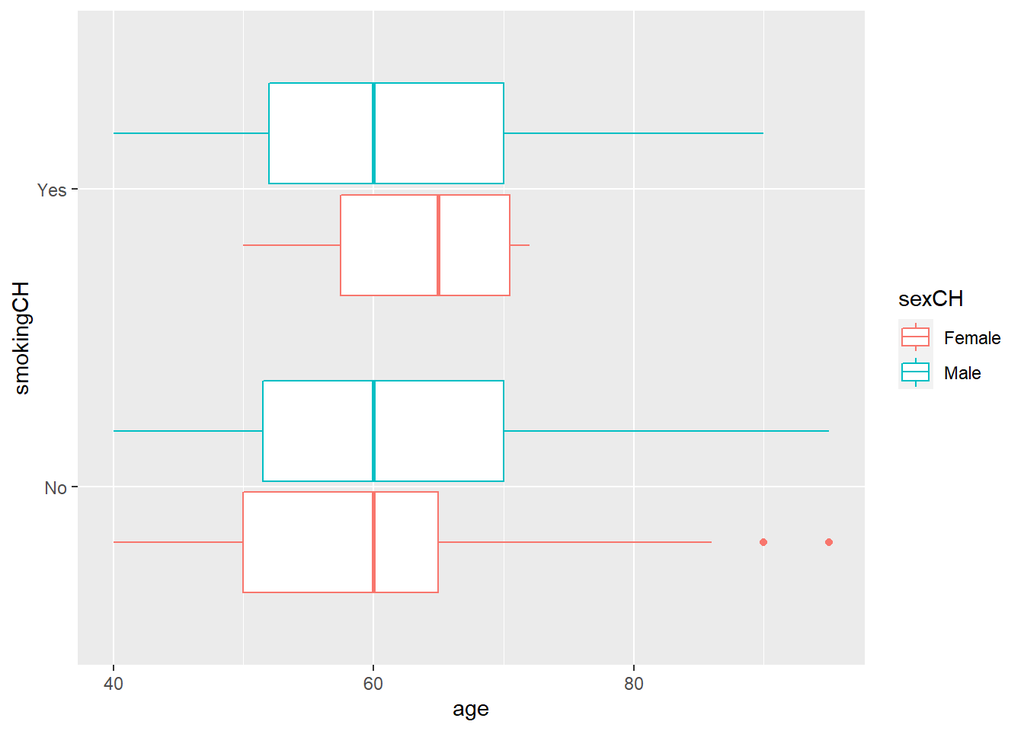

```r
ggplot(data, aes(x = age, y = smokingCH, color = sexCH)) + geom_boxplot()
```

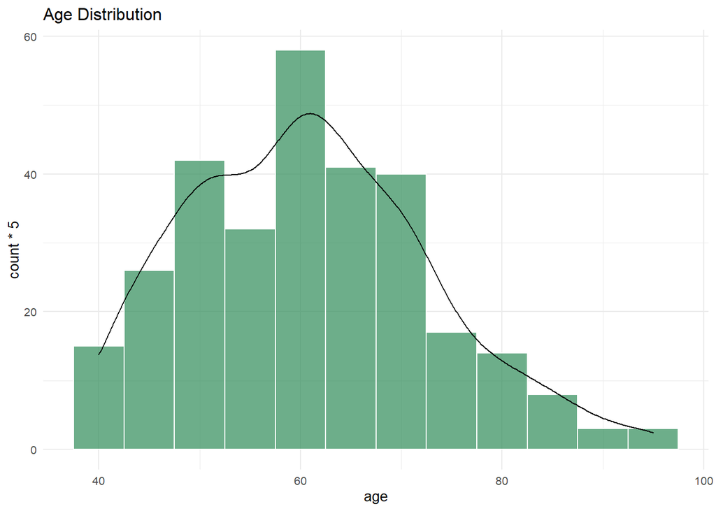

```r
#AGE
ggplot(data, aes(x=age)) + geom_histogram(binwidth = 5, colour = "white", fill="seagreen", alpha = 0.7)+ theme_minimal(base_size = 10) + labs(title = "Age Distribution") + geom_density(eval(bquote(aes(y=..count..*5))),colour="black")
```

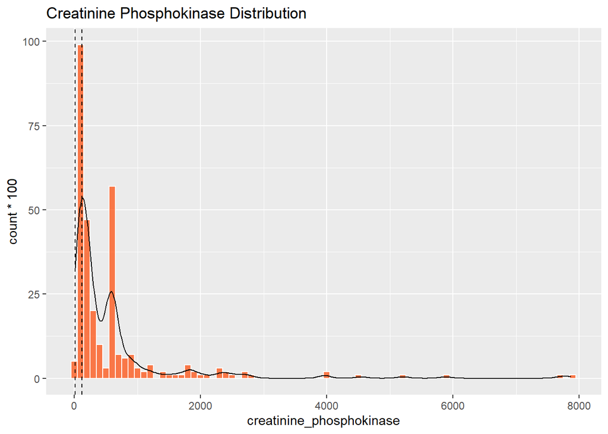

```r
#CPK
ggplot(data, aes(x = creatinine_phosphokinase)) + geom_histogram(binwidth = 100, colour = "white", fill = "orangered", alpha = 0.7) + labs(title = "Creatinine Phosphokinase Distribution") + geom_density(eval(bquote(aes(y=..count.. * 100))),colour="black") + geom_vline(xintercept = 10, linetype = "dashed") + geom_vline(xintercept = 120, linetype = "dashed")
```

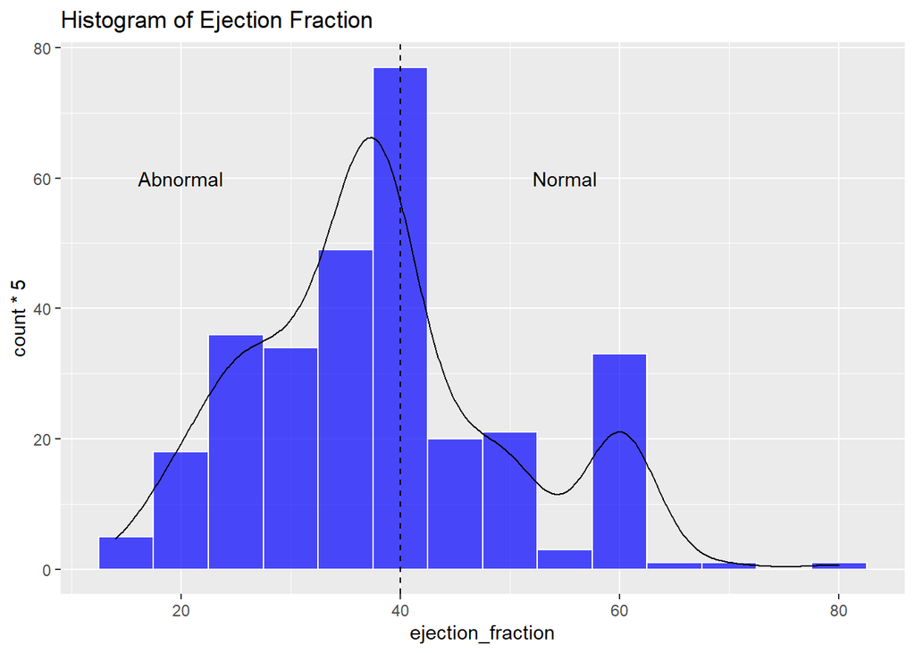

```r
#Ejection Fraction
ggplot(data, aes(x = ejection_fraction )) + geom_histogram(binwidth = 5, colour =  "white", fill = "blue", alpha = 0.7) + labs(title = "Histogram of Ejection Fraction") + geom_density(eval(bquote(aes(y=..count..*5))),colour="black") + geom_vline(xintercept = 40, linetype = "dashed") + annotate("text", x = 20, y = 60, label = "Abnormal") + annotate("text", x = 55, y = 60, label = "Normal")
```

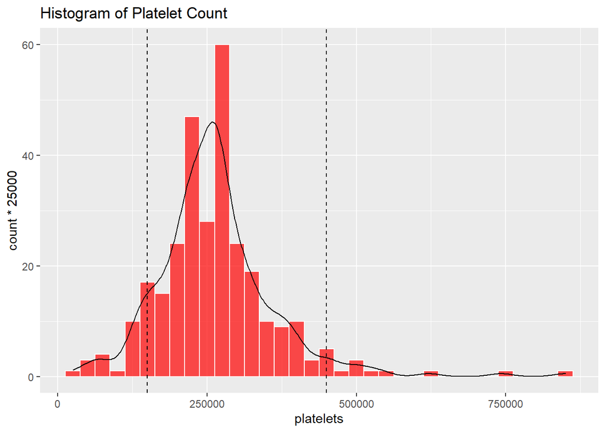

```r
#Platelets
ggplot(data, aes(x = platelets)) + geom_histogram(binwidth = 25000, colour =  "white", fill = "red", alpha = 0.7) + labs(title = "Histogram of Platelet Count") + geom_density(eval(bquote(aes(y=..count.. *25000))),colour="black") + geom_vline(xintercept = 150000, linetype = "dashed") + geom_vline(xintercept = 450000, linetype = "dashed")
```

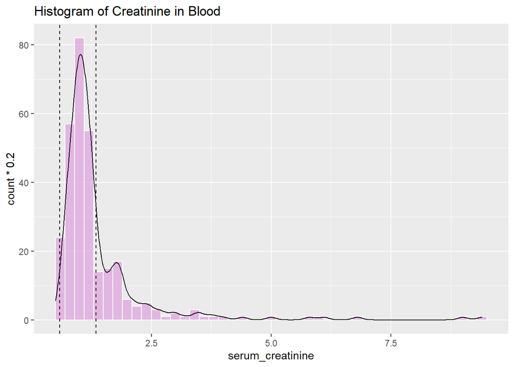

```r
#Serum Creatinine
ggplot(data, aes(x = serum_creatinine)) + geom_histogram(binwidth = 0.2, colour =  "white", fill = "plum", alpha = 0.7) + labs(title = "Histogram of Creatinine in Blood") + geom_density(eval(bquote(aes(y=..count..*0.2))),colour="black") + geom_vline(xintercept = 0.59, linetype = "dashed") + geom_vline(xintercept = 1.35, linetype = "dashed")
```